# rownania_rozniczkowe_1

## Rozwiązywanie równań różniczkowych zwyczajnych

### Zagadnienie początkowe

Rozwiązanie numeryczne równania różniczkowego

\begin{equation} \label{eq:rr1} \frac{dy}{dt}=f(t,y) \end{equation}

z zadanym warunkiem początkowym

\begin{equation} y(t_0)=y_0 \end{equation}

### Funkcja solve_ivp() z scipy.integrate

Zaczniemy od przykładu użycia funkcji scipy.integrate.solve_ivp()

https://docs.scipy.org/doc/scipy/reference/generated/scipy.integrate.solve_ivp.html#scipy.integrate.solve_ivp

do znalezienia numerycznego rozwiązania równania

\begin{equation}\label{eq:prr1} \frac{dy}{dt}=t-y(t) \end{equation}

```python
from scipy.integrate import solve_ivp
def f1(t, y):
    return t-y
y0=[4]
wyn = solve_ivp(f1, [0, 10], y0)
print('t=',wyn.t)
print('\ny=',wyn.y[0])
```

```
t= [ 0.          0.09564003  0.98698806  1.87833608  2.76968411  3.84270492
  5.20002686  6.97269483  9.3934669  10.        ]

y= [4.         3.6395955  1.85147101 1.64337366 2.08359553 2.95027733
 4.22805186 5.97794664 8.39461429 9.00062562]
```

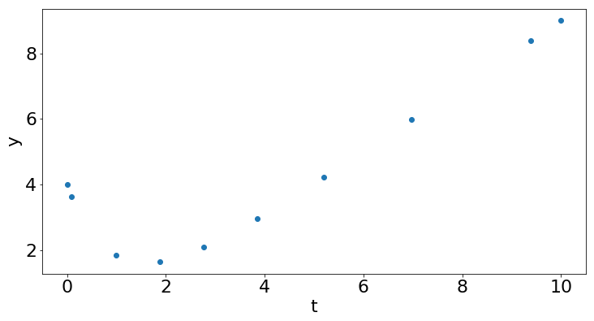

```python
# Teraz wykreślimy to numeryczne rozwiązanie
%matplotlib  inline
import matplotlib.pyplot as plt
plt.rcParams.update({'font.size': 22})
fig,ax1=plt.subplots(figsize=(12, 6))
ax1.plot(wyn.t,wyn.y[0],'o')
ax1.set_xlabel('t')
ax1.set_ylabel('y')
plt.show()
```

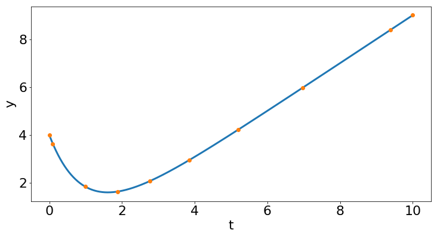

```python
# porównamy ten numeryczny wynik  z dokładnym rozwiązaniem
# y(t)=-1+t +(1+y0)exp(-t)
import numpy as np
ztc=np.arange(0,10,0.01)
def y1_ex(t,y0):
    return -1+t+(1+y0)*np.exp(-t)
#ytc=-1+ztc+5*np.exp(-ztc)
ytc=y1_ex(ztc,y0[0])
plt.rcParams.update({'font.size': 22})
fig,ax1=plt.subplots(figsize=(12, 6))
ax1.plot(ztc,ytc,linewidth=3)
ax1.plot(wyn.t,wyn.y[0],'o')
ax1.set_xlabel('t')
ax1.set_ylabel('y')
plt.show()
```

### Metoda Eulera

Najprostsza metoda numeryczna wykorzystuje rozwinięcie w szereg Taylora y(t+h). Dzięki  
temu, można napisać rozwiązanie równania różniczkowego (\ref{eq:rr1}) w postaci

\begin{equation} \label{eq:mE} y(t+h)=y(t)+hf(t,y)+\mathcal{O}(h^2) \end{equation}

Startując z wartości początkowej $y(t_0)$, metoda ta pozwala obliczyć y w dyskretnych punktach czasowych $y(t_0+h), y(t_0+2h),y(t_0+3h),\ldots$.

Jednak wieloktrotne stosowanie wzoru (\ref{eq:mE}) zmniejsza dokładność rozwiązania do $\mathcal{O}(h)$. Z tego powodu metoda ta nie jest praktycznie stosowana

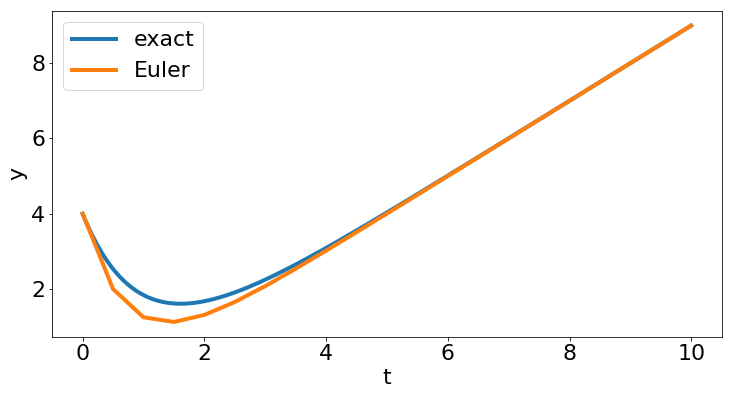

```python
# Przykład rozwiązania równania różniczkowego metodą Eulera
te=[]
ye=[]
h=0.5
t=0
y=4
tkonc=10
te.append(t)
ye.append(y)
while t<tkonc:
    y+=h*f1(t,y)
    t+=h
    te.append(t)
    ye.append(y)
plt.rcParams.update({'font.size': 22})
fig,ax1=plt.subplots(figsize=(12, 6))
#ax1.set_title(tyt)
ax1.plot(ztc,ytc,linewidth=4,label='exact')
ax1.plot(te,ye,linewidth=4,label='Euler')
ax1.set_xlabel('t')
ax1.set_ylabel('y')
ax1.legend()
plt.show()
```

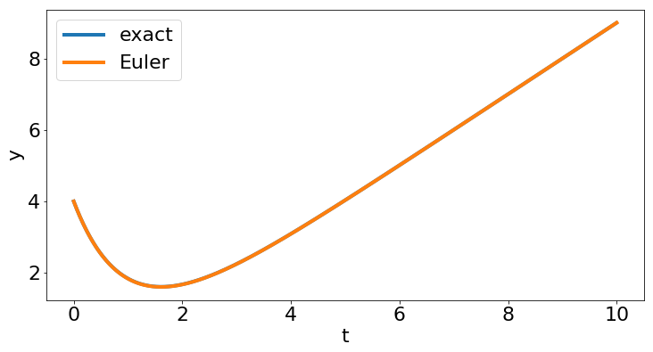

```python
# Żeby poprawić dokładnośc rozwiązania zmniejszymy h 1stukrotnie
te=[]
ye=[]
h=0.005
t=0
y=4
tkonc=10
te.append(t)
ye.append(y)
while t<tkonc:
    y+=h*f1(t,y)
    t+=h
    te.append(t)
    ye.append(y)
plt.rcParams.update({'font.size': 22})
fig,ax1=plt.subplots(figsize=(12, 6))
#ax1.set_title(tyt)
ax1.plot(ztc,ytc,linewidth=4,label='exact')
ax1.plot(te,ye,linewidth=4,label='Euler')
ax1.set_xlabel('t')
ax1.set_ylabel('y')
ax1.legend()
plt.show()
```

### Metoda Rungego-Kutty.

Przedstawimy tutaj metodę czwartego rzędu, w której y(t+h) obliczane jest z dokładnością $\mathcal{O}(h^5)$

\begin{equation} \label{eq:mRK4} y(t+h)=y(t)+\frac{1}{6}\left(k_1+2k_2+2k_3+k_4 \right) \end{equation}

gdzie \begin{eqnarray*} k_1&=&hf(t,y),\\ k_2&=&hf(t+\frac{h}{2},y+\frac{k_1}{2}),\\ k_3&=&hf(t+\frac{h}{2},y+\frac{k_2}{2}),\\ k_4&=&hf(t+h,y+k_3) \end{eqnarray*}

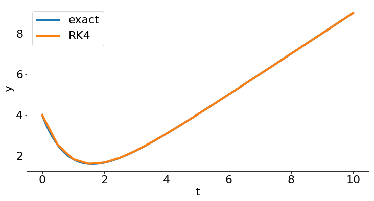

```python
def RK4(f,t,y,h):
    k1=h*f(t,y)
    k2=h*f(t+h/2,y+k1/2)
    k3=h*f(t+h/2,y+k2/2)
    k4=h*f(t+h,y+k3)
    return y+(k1+2*k2+2*k3+k4)/6
trk=[]
yrk=[]
h=0.5
t=0
y=4
tkonc=10
trk.append(t)
yrk.append(y)
while t<tkonc:
    y=RK4(f1,t,y,h)
    t+=h
    trk.append(t)
    yrk.append(y)

plt.rcParams.update({'font.size': 22})
fig,ax1=plt.subplots(figsize=(12, 6))
#ax1.set_title(tyt)
ax1.plot(ztc,ytc,linewidth=4,label='exact')
ax1.plot(trk,yrk,linewidth=4,label='RK4')
ax1.set_xlabel('t')
ax1.set_ylabel('y')
ax1.legend()
plt.show()
```

Porównamy wyniki otrzymane metodą Eulera i RK4 otrzymane dla równania różniczkowego

\begin{equation}\label{eq:E_RK4} \frac{dy}{dt}=-k y(t) \end{equation}

dla $0<t<1$ i $k=5$.

Rozwiązania równania (\ref{eq:E_RK4}) z krokiem $h=0.05, 0.1, 0.15, 0.2$ otrzymane obiema metodami porównamy z dokładnym rozwiązaniem

$$ y(t)=e^{-kt} $$

```python
k=5
def ftest(t, y):
    return -k*y
def ytest_ex(t,y):
    return np.exp(-k*t)

def E(f,t0,tk,h,y0):
    te=[]
    ye=[]
    t=t0
    y=y0
    te.append(t)
    ye.append(y)
    while t<tk:
        y+=h*f(t,y)
        t+=h
        if t<(tk+0.001):
            te.append(t)
            ye.append(y)
    return te,ye
```

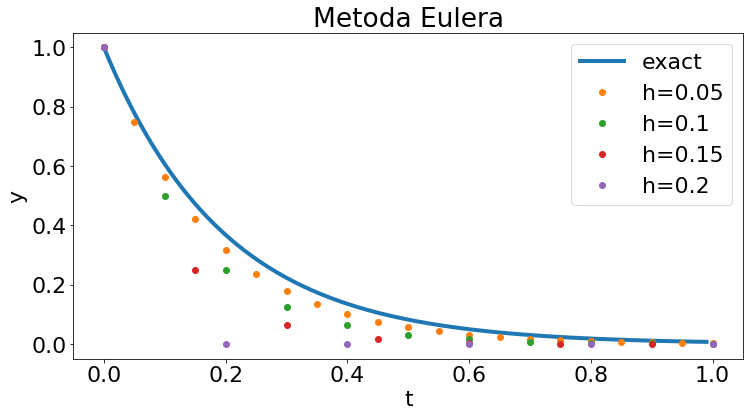

```python
t0=0
tk=1.0
y0=1.0
tyt='Metoda Eulera'
xtc=np.arange(0,1.0,0.01)
yex=ytest_ex(xtc,y0)
plt.rcParams.update({'font.size': 22})
fig,ax1=plt.subplots(figsize=(12, 6))
ax1.set_title(tyt)
ax1.plot(xtc,yex,linewidth=4,label='exact')
ax1.set_xlabel('t')
ax1.set_ylabel('y')
for h in np.arange(0.05,0.201,0.05):
    tw,yw= E(ftest,t0,tk,h,y0)
    hlab='h='+str(np.round(h,2))
    ax1.plot(tw,yw,'o',label=hlab)
ax1.legend()
plt.show()
```

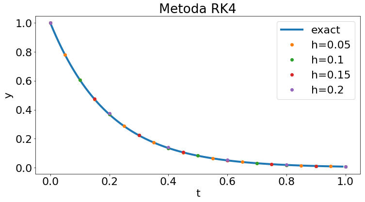

```python
def R_K(f,t0,tk,h,y0):
    tr=[]
    yr=[]
    t=t0
    y=y0
    tr.append(t)
    yr.append(y)
    while t<tk:
        y=RK4(f,t,y,h)
        t+=h
        if t<(tk+0.001):
            tr.append(t)
            yr.append(y)
    return tr,yr
t0=0
tk=1.0
y0=1.0
tyt='Metoda RK4'
plt.rcParams.update({'font.size': 22})
fig,ax1=plt.subplots(figsize=(12,6))
ax1.set_title(tyt)
ax1.plot(xtc,yex,linewidth=4,label='exact')
ax1.set_xlabel('t')
ax1.set_ylabel('y')
for h in np.arange(0.05,0.201,0.05):
    tr,yr= R_K(ftest,t0,tk,h,y0)
    hlab='h='+str(np.round(h,2))
    ax1.plot(tr,yr,'o',label=hlab)
ax1.legend()
plt.show()
```

### Opcje metody solve_ivp()

W funkcji scipy.integrate.solve_ivp() domyślną metodą rozwiązywania równania/równań różniczowych jest adaptacyjna metoda RK45 wykorzystująca jawne metody Rungego-Kutty czwartego i piątego rzędu. Metoda czwartego rzędu służy do oszacowania błędu,a długość kroku jest wybierana tak, aby błąd całkowania był mniej więcej stały.

Rozwiążemy teraz pierwsze przykładowe równanie różniczkowe (\ref{eq:prr1}) z domyślną i większą dokładnością. W tym drugim przypadku ustawimy atol=1e-12,rtol=1e-9.

```python
# Rozwiązania  z domyślną i większą dokładnością (atol=1e-12,rtol=1e-9)


wdom = solve_ivp(f1, [0, 10], [4])
print('t=',wdom.t)
print('y=',wdom.y[0])
wprec = solve_ivp(f1, [0, 10], [4],atol=1e-12,rtol=1e-9)
print('\n')
print('t=',wprec.t)
print('y=',wprec.y[0])
```

```
t= [ 0.          0.09564003  0.98698806  1.87833608  2.76968411  3.84270492
  5.20002686  6.97269483  9.3934669  10.        ]
y= [4.         3.6395955  1.85147101 1.64337366 2.08359553 2.95027733
 4.22805186 5.97794664 8.39461429 9.00062562]


t= [0.00000000e+00 6.03447802e-03 6.26784202e-02 1.19322362e-01
 1.75966304e-01 2.32610247e-01 2.89254189e-01 3.45898131e-01
 4.02542073e-01 4.59186015e-01 5.15899312e-01 5.72715916e-01
 6.29655265e-01 6.86738508e-01 7.43988467e-01 8.01429687e-01
 8.59088472e-01 9.16992922e-01 9.75172952e-01 1.03366031e+00
 1.09248857e+00 1.15169314e+00 1.21131122e+00 1.27138181e+00
 1.33194564e+00 1.39304515e+00 1.45472446e+00 1.51702929e+00
 1.58000694e+00 1.64370623e+00 1.70817865e+00 1.77350717e+00
 1.83974471e+00 1.90694615e+00 1.97516781e+00 2.04446743e+00
 2.11490430e+00 2.18653926e+00 2.25943482e+00 2.33365528e+00
 2.40926682e+00 2.48633771e+00 2.56493845e+00 2.64514198e+00
 2.72702391e+00 2.81066280e+00 2.89614042e+00 2.98354207e+00
 3.07295696e+00 3.16447857e+00 3.25820510e+00 3.35423991e+00
 3.45269212e+00 3.55367709e+00 3.65731717e+00 3.76374231e+00
 3.87309095e+00 3.98551085e+00 4.10116009e+00 4.22020820e+00
 4.34283739e+00 4.46924401e+00 4.59964007e+00 4.73425514e+00
 4.87333838e+00 5.01716093e+00 5.16601862e+00 5.32023515e+00
 5.48016569e+00 5.64620118e+00 5.81877325e+00 5.99836007e+00
 6.18549325e+00 6.38076600e+00 6.58484294e+00 6.79847185e+00
 7.02249787e+00 7.25788094e+00 7.50571703e+00 7.76726463e+00
 8.04397772e+00 8.33754751e+00 8.64995553e+00 8.98354232e+00
 9.34109703e+00 9.72597627e+00 1.00000000e+01]
y= [4.         3.97595294 3.75890576 3.55693062 3.36919751 3.19492214
 3.03336338 2.88382095 2.74563311 2.61817457 2.5007168  2.39267393
 2.29353244 2.20281164 2.12006223 2.0448648  1.97682838 1.91558904
 1.86080857 1.81217328 1.76939275 1.7321987  1.70034389 1.67360098
 1.65176156 1.63463508 1.62204788 1.6138422  1.60987528 1.61001842
 1.61415621 1.62219041 1.63403459 1.64961262 1.66885795 1.69171299
 1.71812847 1.74806293 1.78148221 1.81835904 1.85867267 1.90240853
 1.94955803 2.00011834 2.0540923  2.11148831 2.1723204  2.23660827
 2.30437742 2.37565937 2.45049191 2.52891949 2.61099356 2.69677315
 2.78632537 2.87972615 2.97706094 3.0784256  3.18392739 3.29368612
 3.40783535 3.52652387 3.64991734 3.7782001  3.91157734 4.05027745
 4.19455486 4.34469317 4.50100889 4.66385571 4.83362949 5.01077417
 5.19578868 5.38923513 5.59174867 5.80404924 6.02695585 6.26140394
 6.50846669 6.76938148 7.04558287 7.3387443  7.6508312  7.98416961
 8.34153575 8.72627483 9.000227  ]
```

```python
# Obliczymy błąd rozwiązań w t=10
print("dom:  %10.4e  n=%3d" % (y1_ex(wdom.t[-1],4)-wdom.y[0,-1],len(wdom.t)))
print("prec: %10.4e  n=%3d" % (y1_ex(wprec.t[-1],4)-wprec.y[0,-1],len(wprec.t)))
```

```
dom:  -3.9862e-04  n= 10
prec: -1.1303e-09  n= 87
```

Widzimy, że funkcja \textit{solve_ivp()} zwraca rozwiązania w punktach czasowych ustalanych przez metodę adaptacyjną RK45, których liczba zależy od dokładności.

Możemy uzyskać wartości y(t) w ustalonych punktach czasowych za pomocą opcji \textit{t_eval}.

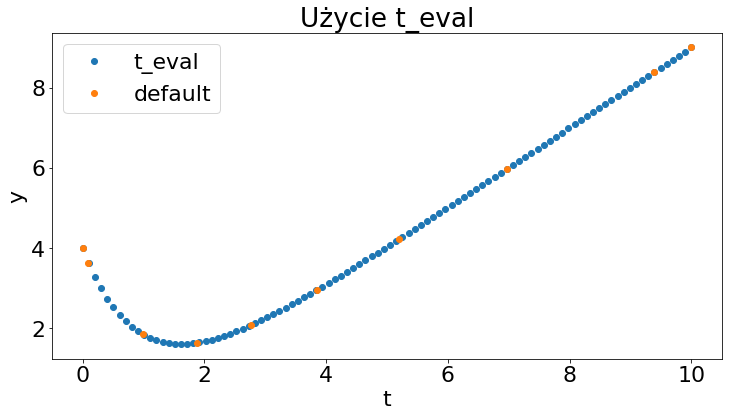

```python
# Użycie opcji t_eval
y0=[4]

# domyślnie  t_eval=None
wyn1 = solve_ivp(f1, [0, 10], y0)

# rozwiązanie w 100 punktach czasowych
tzak= zx=np.linspace(0, 10,num=100, endpoint=True)
wyn2 = solve_ivp(f1, [0, 10], y0,t_eval=tzak)
# wykresy tych dwóch zbiorów
plt.rcParams.update({'font.size': 22})
fig,ax1=plt.subplots(figsize=(12, 6))
ax1.set_title('Użycie t_eval')

ax1.plot(wyn2.t,wyn2.y[0],'o',label='t_eval')
ax1.plot(wyn1.t,wyn1.y[0],'o',label='default')
ax1.set_xlabel('t')
ax1.set_ylabel('y')
ax1.legend()
plt.show()
```

Teraz pokażemy jak można użyć funkcji solve_ivp() do rozwiązaniay równania różniczkowego z dwoma parametrami

\begin{equation} \frac{dy}{dt}=a(1-y)-by \end{equation}

dla warunku początkowego $y(t=0)=0$

Ponieważ funkcja solve_ivp() nie ma opcji args=() to wartości parametrów a i b można przekazać do solve_ivp() używając funkcji lambda

\begin{textboxa} solve_ivp(lambda t,y:f(t,y,a,b), t_span, y0) \end{textboxa}

```python
def f2(t, y,a,b):
    return a*(1-y)-b*y
a=0.1
b=0.6
y20=[0]

# Przekazanie  wartości parametrów a i b za pomocą  funkcji lambda

wyn2 = solve_ivp(lambda t,y:f2(t,y,a,b), [0, 50], y20)
print(wyn2.t)
print(wyn2.y[0])
```

```
[0.00000000e+00 1.00000000e-04 1.10000000e-03 1.11000000e-02
 1.11100000e-01 9.21023477e-01 2.04827952e+00 3.41202025e+00
 5.04628928e+00 7.02429612e+00 9.48031792e+00 1.26457415e+01
 1.69119360e+01 2.26540562e+01 2.74010073e+01 3.23782550e+01
 3.73555027e+01 4.16702899e+01 4.60901311e+01 5.00000000e+01]
[0.00000000e+00 9.99965001e-06 1.09957661e-04 1.10569880e-03
 1.06889724e-02 6.78824143e-02 1.08791303e-01 1.29731674e-01
 1.38662073e-01 1.41791486e-01 1.42650829e-01 1.42819499e-01
 1.42836410e-01 1.42786716e-01 1.42784578e-01 1.42757070e-01
 1.42719134e-01 1.42776146e-01 1.42802591e-01 1.42838037e-01]
```

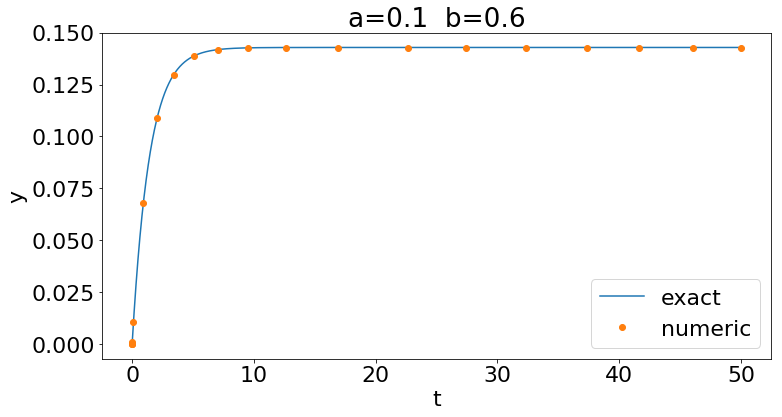

```python
#  porównamy ten numeryczny wynik  z dokładnym rozwiązaniem
# y(t)=a/(a+b)*(1-exp(-(a+b)*t))

zt2=np.arange(0,50,0.01)
yt2=a/(a+b)*(1-np.exp(-(a+b)*zt2))


plt.rcParams.update({'font.size': 22})
fig,ax1=plt.subplots(figsize=(12, 6))
tyt='a='+str(a)+'  b='+str(b)
ax1.set_title(tyt)

ax1.plot(zt2,yt2,label='exact')
ax1.plot(wyn2.t,wyn2.y[0],'o',label='numeric')
ax1.set_xlabel('t')
ax1.set_ylabel('y')
ax1.legend()
plt.show()
```

### Równania różniczkowe wyższych rzędów

Równania różniczkowe wyższych rzędów, np

\begin{equation} \frac{d^2y}{dt^2}=-4y \end{equation}

należy sprowadzić do układu równań pierwszego rzędu.

Można to zrobić wprowadzając zmienną $\dot{y}=\frac{dy}{dt}$, dzięki czemu otrzymamy układ dwóch równań pierwszego rzędu

\begin{eqnarray} \frac{dy}{dt}&=&\dot{y},\\ \frac{d\dot{y}}{dt}&=&-4y \end{eqnarray}

W tym przypadku, potrzebujemy dwie wartości początkowe $y(t_0)$ i $\dot{y}(t_0)$

Użyjemy teraz funkcji solve_ivp() do rozwiązania tego układu z warunkami początkowymi $y(t=0)=0$ i $\dot{y}(t=0)=1$

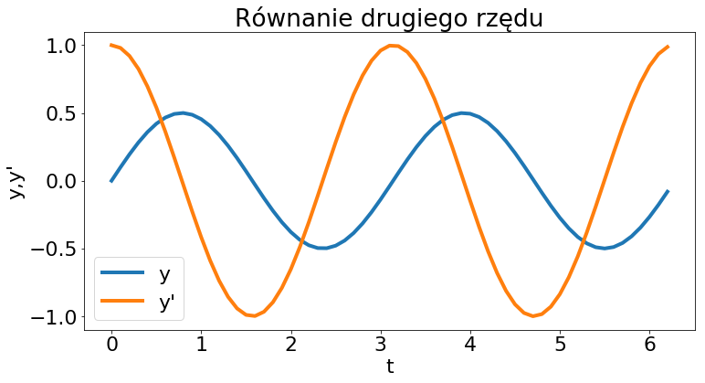

```python
# y->y[0], y'-> y[1]
def f3(t, y): return [y[1],-4*y[0]]
y30=[0,1]
t_ob3=np.arange(0,2*np.pi,0.1)
w3 = solve_ivp(f3, [0, 10], y30,t_eval=t_ob3)


plt.rcParams.update({'font.size': 22})
fig,ax1=plt.subplots(figsize=(12, 6))
tyt='Równanie drugiego rzędu'
ax1.set_title(tyt)

ax1.plot(t_ob3,w3.y[0],linewidth=4,label='y')
ax1.plot(t_ob3,w3.y[1],linewidth=4,label="y'")
ax1.set_xlabel('t')
ax1.set_ylabel("y,y'")
ax1.legend()
plt.show()
```

Przykład układu 3 równań.

\begin{eqnarray} \frac{dx}{dt}&=&s(y-x),\\ \frac{dy}{dt}&=&-xz+rx-y,\\ \frac{dz}{dt}&=&xy-bz \end{eqnarray}

Dla $s=10$, $b=\frac{8}{3}$ i $r>24.874$ rozwiązaniem jest atraktor Lorentza

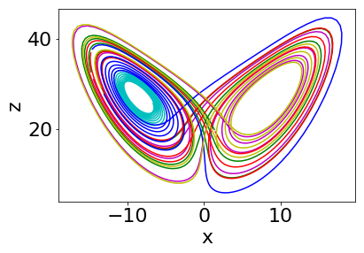

```python
# Atraktor Lorenza

s=10.0
b=8/3
r=28
# x->y[0], y->y[1],z->y[2]
def Lorentz(t, y,s,b,r):
    return [s*(y[1]-y[0]),-y[0]*y[2]+r*y[0]-y[1],y[0]*y[1]-b*y[2]]

# warunki początkowe x(0), y(0) i z(0)
yL0 = [0.00, 1.0,1.05]
# czasowe punkty obliczeniowe
tp = np.arange(0.0,100.0,0.01)

atr = solve_ivp(lambda t,y:Lorentz(t,y,s,b,r), [0, 100], yL0,method='Radau',t_eval=tp)

#zmiana koloru co 500 kroków czasowych
licol=('c','w','m','g','r','b','y')
n_i=(500,1000,1500,2000,2500,3000,3500,4000)

for i in range (len(licol)):
    plt.plot(atr.y[0,n_i[i]:n_i[i+1]],atr.y[2,n_i[i]:n_i[i+1] ],color=licol[i])
plt.xlabel('x')
plt.ylabel('z')
plt.show()
```

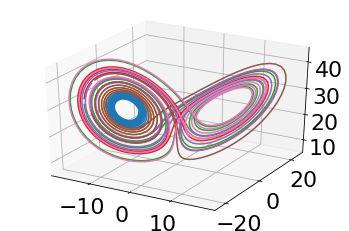

```python
# 3D wykres
import matplotlib as mpl
from mpl_toolkits.mplot3d import Axes3D
import matplotlib.pyplot as plt
fig=plt.figure()
ax=fig.gca(projection='3d')

for i in range (len(licol)):
    ax.plot(atr.y[0,n_i[i]:n_i[i+1]],atr.y[1,n_i[i]:n_i[i+1]],atr.y[2,n_i[i]:n_i[i+1]])
plt.show()
```

### Rzut pionowy z siłą oporu powietrza

Rzut pionowy ciała o masie m w polu grawitacyjnym z siłą oporu powietrza proporcjonalną do kwadratu prędkości i skierowaną przeciwnie do prędkości.

Równanie ruchu

\begin{equation}\label{eq:rzp1} \ddot{y}=-\frac{\rho}{m}v\left|v\right|-g \end{equation}

gdzie $v=\frac{dy}{dt},\;\;\;g=9.81\frac{m}{s^2}$.

Równanie (\ref{eq:rzp1}) można sprowadzić do następujacego ukladu dwóch równań różniczkowych pierwszego rzędu

\begin{eqnarray} \frac{dy}{dt}&=&v,\\ \frac{dv}{dt}&=&-\frac{\rho}{m}v\left|v\right|-g \end{eqnarray}

```python
# y - lista o 2 składowych: y[0] = y, a y[1] = v
# warunki początkowe  y0, vo
def f4(t,y,m,ra):
    return [y[1],-9.81 -ra/m*y[1]*np.abs(y[1])]
# initial condition
m=50.0
ro=10.1

y_0=0.1
v_0=10
t_max=10

y40 = [y_0, v_0]
t_ob4 = np.arange(0,t_max,1)

w4 = solve_ivp(lambda t,y:f4(t,y,m,ro), [0,t_max], y40)
print(w4.y[0,-1])
```

```
-58.63117104458684
```

W tym przypadku trudno jest określić czas, gdy spadające ciało osiągnie poziom y=0. Można pokonać tę trudność wykorzystując opcję \textit{events} w funkcji \textit{solve_ivp()}.

Deklarujemy warunek w postaci funkcji czasu t położenia y[0] i prędkości y[1]

$$ grunt(t,y)=y[0], $$

dla którego solve_ivp() oblicza pierwiastki równania

$$ grunt(t,y)=0 $$

czyli znajduje czas, gdy y[0]=0.

Po znalezieniu tego czasu możemy przerwać obliczenia ustawiając

$grunt.terminal = True$

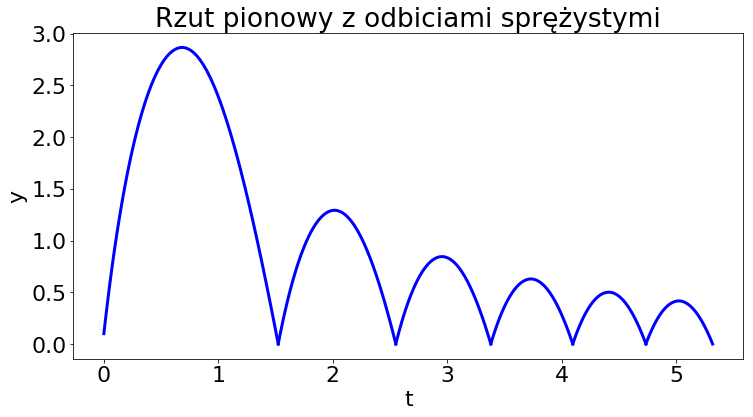

```python
# Warunek  na osiągnięcie gruntu  przez spadające ciało
def grunt(t,y):
    return y[0]
# solve_ivp() oblicza pierwiastki równania grunt(t,y)=0

# Przerwanie obliczeń po kontakcie z gruntem
grunt.terminal = True

y_0=0.1
v_0=10
t_max=10
y40 = [y_0, v_0]
w4 = solve_ivp(lambda t,y:f4(t,y,m,ro), [0,t_max], y40,events=grunt,atol=1e-12,rtol=1e-10)
plt.rcParams.update({'font.size': 22})
fig,ax1=plt.subplots(figsize=(12, 6))
tyt='Rzut pionowy z odbiciami sprężystymi'
ax1.set_title(tyt)

ax1.plot(w4.t,w4.y[0],linewidth=3,color='blue')



# Wykorzystamy ten warunek do wprowadzenia odbić
# Po obliczeniu czasu kontaktu z gruntem zmieniamy v => -v i rozwiązujemy nowe
for i in range(5):
    y40=[np.abs(w4.y[0,-1]),-w4.y[1,-1]]
    w4 = solve_ivp(lambda t,y:f4(t,y,m,ro), [w4.t[-1],t_max], y40,events=grunt,atol=1e-12,rtol=1e-10)
    ax1.plot(w4.t,w4.y[0],linewidth=3,color='blue')

ax1.set_xlabel('t')
ax1.set_ylabel("y")

plt.show()
```

### Przykład problemu sztywnego

```python
#problem sztywny
def f5(t,y):
    return [y[1],-1001.0*y[1]-1000.0*y[0] ]
y50=[0,1.0]

# Sprawdzimy jak radzą sobie z tym problemem metody dostępne w solve_ivp()

wyn5a = solve_ivp(f5, [0, 10], y50)

wyn5b = solve_ivp(f5, [0, 10], y50,method='RK23')

wyn5c = solve_ivp(f5, [0, 10], y50,method='LSODA')

wyn5d = solve_ivp(f5, [0, 10], y50,method='BDF')
```

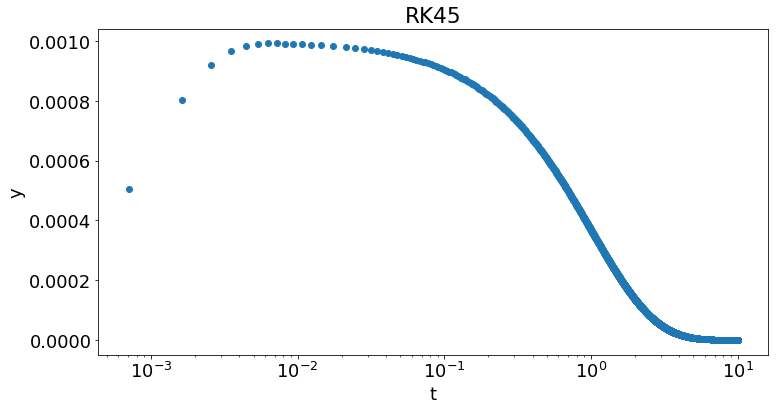

```python
# RK45
tyt='RK45'
plt.rcParams.update({'font.size': 18})
fig,ax1=plt.subplots(figsize=(12, 6))
ax1.set_title(tyt)
ax1.semilogx(wyn5a.t,wyn5a.y[0],'o',label='rk45')
ax1.set_xlabel('t')
ax1.set_ylabel("y")
plt.show()
```

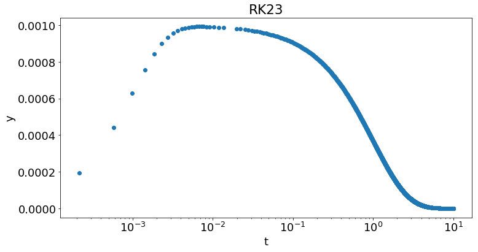

```python
# RK23
tyt='RK23'
plt.rcParams.update({'font.size': 18})
fig,ax1=plt.subplots(figsize=(12, 6))
ax1.set_title(tyt)
ax1.semilogx(wyn5b.t,wyn5b.y[0],'o',label='rk23')
ax1.set_xlabel('t')
ax1.set_ylabel("y")
plt.show()
```

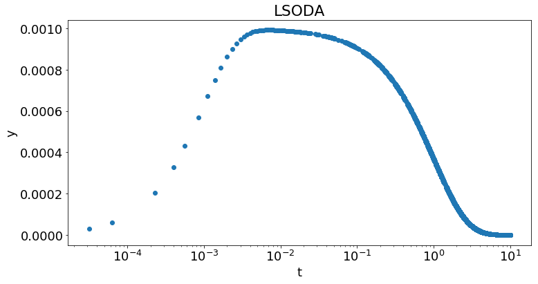

```python
# LSODA
tyt='LSODA'
plt.rcParams.update({'font.size': 18})
fig,ax1=plt.subplots(figsize=(12, 6))
ax1.set_title(tyt)
ax1.semilogx(wyn5c.t,wyn5c.y[0],'o',label='LSODA')
ax1.set_xlabel('t')
ax1.set_ylabel("y")
plt.show()
```

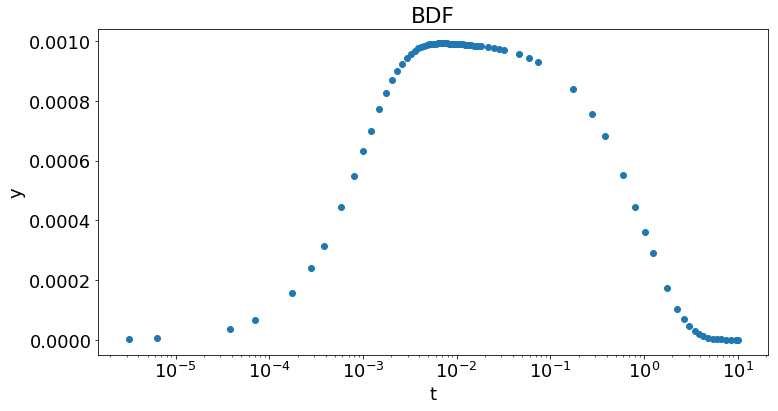

```python
# BDF
tyt='BDF'
plt.rcParams.update({'font.size': 18})
fig,ax1=plt.subplots(figsize=(12, 6))
ax1.set_title(tyt)
ax1.semilogx(wyn5d.t,wyn5d.y[0],'o',label='BDF')
ax1.set_xlabel('t')
ax1.set_ylabel("y")
plt.show()
```

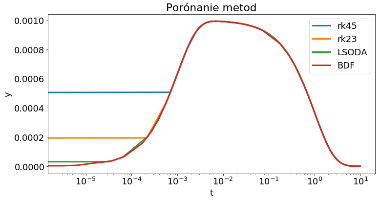

```python
# Porónanie metod

tyt='Porónanie metod'
plt.rcParams.update({'font.size': 18})
fig,ax1=plt.subplots(figsize=(12, 6))
ax1.set_title(tyt)
ax1.semilogx(wyn5a.t,wyn5a.y[0],linewidth=3,label='rk45')
ax1.semilogx(wyn5b.t,wyn5b.y[0],linewidth=3,label='rk23')
ax1.semilogx(wyn5c.t,wyn5c.y[0],linewidth=3,label='LSODA')
ax1.semilogx(wyn5d.t,wyn5d.y[0],linewidth=3,label='BDF')
ax1.set_xlabel('t')
ax1.set_ylabel("y")
ax1.legend()
plt.show()
```

Widzimy, że najlepiej spisała się metoda BDF, a LSODA nieco gorzej w zakresie t bliskich 0.